# AmazonReviewModeling

Sofia Caceres

2026-04-21

# Full Dataset Summary

This report uses the full Amazon review dataset processed with `analyze_reviews.sh`. The original full data file has one truncated final line, so the analysis uses the complete review records.

```r
total_reviews
```

```
## [1] 6427547
```

```r
ratings_summary %>%
  rename(
    Rating = rating,
    Count = count,
    Percent = percent
  ) %>%
  kable()
```

| Rating | Count | Percent |
| --- | --- | --- |
| 1 | 572868 | 8.91 |
| 2 | 290055 | 4.51 |
| 3 | 437555 | 6.81 |
| 4 | 913751 | 14.22 |
| 5 | 4213318 | 65.55 |

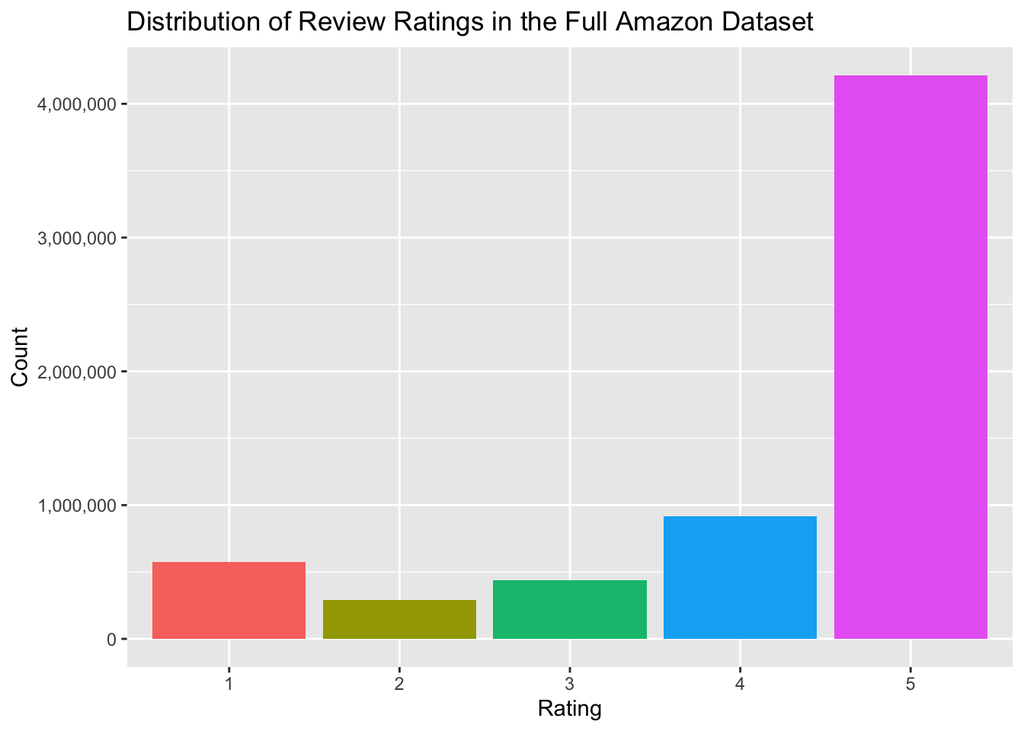

```r
ggplot(ratings_summary, aes(x = factor(rating), y = count, fill = factor(rating))) +
  geom_col(show.legend = FALSE) +
  scale_y_continuous(labels = function(x) format(x, big.mark = ",", scientific = FALSE)) +
  labs(
    title = "Distribution of Review Ratings in the Full Amazon Dataset",
    x = "Rating",
    y = "Count"
  )
```

# Word Counts

For the good/bad comparison, 1-star and 2-star reviews are labeled bad, while 4-star and 5-star reviews are labeled good. Three-star reviews are counted in the rating distribution but excluded from the good/bad word comparison.

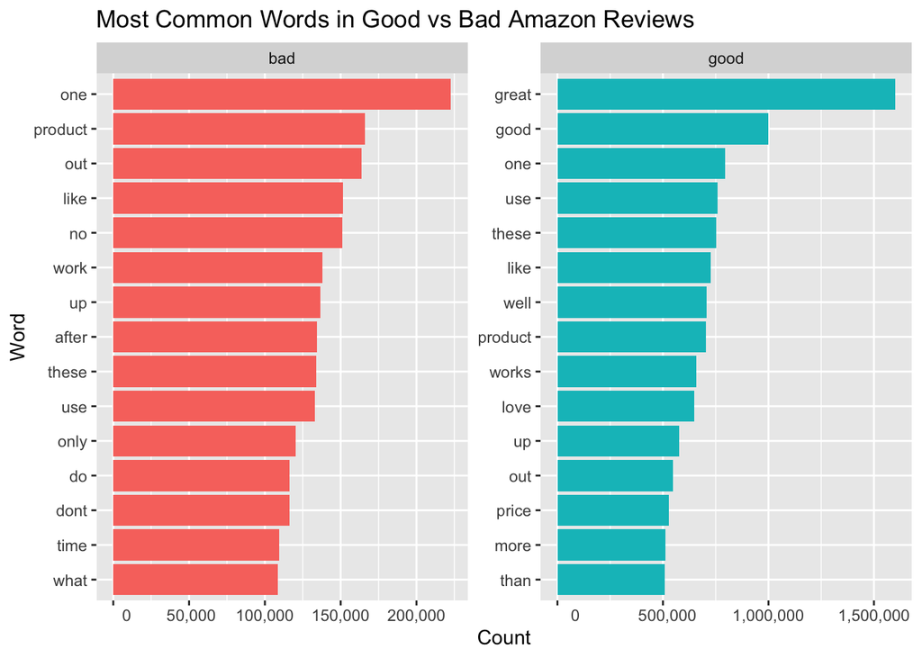

```r
top_words <- review_word_counts %>%
  group_by(review_label) %>%
  slice_max(n, n = 15) %>%
  ungroup()

ggplot(top_words, aes(x = reorder_within(word, n, review_label), y = n, fill = review_label)) +
  geom_col(show.legend = FALSE) +
  facet_wrap(~ review_label, scales = "free") +
  scale_x_reordered() +
  scale_y_continuous(labels = function(x) format(x, big.mark = ",", scientific = FALSE)) +
  coord_flip() +
  labs(
    title = "Most Common Words in Good vs Bad Amazon Reviews",
    x = "Word",
    y = "Count"
  )
```

```r
word_counts %>%
  filter(total >= 1000) %>%
  arrange(difference) %>%
  head(20)
```

```
## # A tibble: 20 x 7
##    word            bad  good total bad_prop good_prop difference
##    <chr>         <int> <int> <int>    <dbl>     <dbl>      <dbl>
##  1 scam           1685   258  1943    0.867     0.133     -0.734
##  2 refund        18073  3089 21162    0.854     0.146     -0.708
##  3 unacceptable   2323   444  2767    0.840     0.160     -0.679
##  4 deceptive      1044   231  1275    0.819     0.181     -0.638
##  5 worthless      6103  1430  7533    0.810     0.190     -0.620
##  6 waste         40450 10087 50537    0.800     0.200     -0.601
##  7 returning     15703  4014 19717    0.796     0.204     -0.593
##  8 worst         14610  3771 18381    0.795     0.205     -0.590
##  9 paperweight     846   225  1071    0.790     0.210     -0.580
## 10 disappointing 10486  2854 13340    0.786     0.214     -0.572
## 11 unusable       5537  1517  7054    0.785     0.215     -0.570
## 12 dissatisfied   1614   446  2060    0.783     0.217     -0.567
## 13 junk          22087  6582 28669    0.770     0.230     -0.541
## 14 expired        3349  1013  4362    0.768     0.232     -0.536
## 15 useless       19803  6010 25813    0.767     0.233     -0.534
## 16 pos            1517   463  1980    0.766     0.234     -0.532
## 17 poorly        10173  3198 13371    0.761     0.239     -0.522
## 18 horrible      18399  5936 24335    0.756     0.244     -0.512
## 19 return        55980 18877 74857    0.748     0.252     -0.496
## 20 returned      26888  9101 35989    0.747     0.253     -0.494
```

```r
word_counts %>%
  filter(total >= 1000) %>%
  arrange(desc(difference)) %>%
  head(20)
```

```
## # A tibble: 20 x 7
##    word          bad   good  total bad_prop good_prop difference
##    <chr>       <int>  <int>  <int>    <dbl>     <dbl>      <dbl>
##  1 excelente      14   3887   3901  0.00359     0.996      0.993
##  2 excelent       18   4217   4235  0.00425     0.996      0.991
##  3 linteater       7   1231   1238  0.00565     0.994      0.989
##  4 yum            49   6120   6169  0.00794     0.992      0.984
##  5 addicting      12   1076   1088  0.0110      0.989      0.978
##  6 compliments   116   8591   8707  0.0133      0.987      0.973
##  7 yummy         155  11213  11368  0.0136      0.986      0.973
##  8 lifesaver      28   1854   1882  0.0149      0.985      0.970
##  9 pleasantly    150   9870  10020  0.0150      0.985      0.970
## 10 invaluable     20   1283   1303  0.0153      0.985      0.969
## 11 awsome         46   2866   2912  0.0158      0.984      0.968
## 12 loves        1600  98751 100351  0.0159      0.984      0.968
## 13 prefect        28   1702   1730  0.0162      0.984      0.968
## 14 complements    18   1093   1111  0.0162      0.984      0.968
## 15 godsend        18   1077   1095  0.0164      0.984      0.967
## 16 luv            27   1548   1575  0.0171      0.983      0.966
## 17 unbeatable     40   2148   2188  0.0183      0.982      0.963
## 18 perfect      7294 361664 368958  0.0198      0.980      0.960
## 19 arsenal        26   1261   1287  0.0202      0.980      0.960
## 20 excellent    4090 196948 201038  0.0203      0.980      0.959
```

```r
bad_words <- word_counts %>%
  filter(total >= 1000) %>%
  arrange(difference) %>%
  head(20)

good_words <- word_counts %>%
  filter(total >= 1000) %>%
  arrange(desc(difference)) %>%
  head(20)

bad_words
```

```
## # A tibble: 20 x 7
##    word            bad  good total bad_prop good_prop difference
##    <chr>         <int> <int> <int>    <dbl>     <dbl>      <dbl>
##  1 scam           1685   258  1943    0.867     0.133     -0.734
##  2 refund        18073  3089 21162    0.854     0.146     -0.708
##  3 unacceptable   2323   444  2767    0.840     0.160     -0.679
##  4 deceptive      1044   231  1275    0.819     0.181     -0.638
##  5 worthless      6103  1430  7533    0.810     0.190     -0.620
##  6 waste         40450 10087 50537    0.800     0.200     -0.601
##  7 returning     15703  4014 19717    0.796     0.204     -0.593
##  8 worst         14610  3771 18381    0.795     0.205     -0.590
##  9 paperweight     846   225  1071    0.790     0.210     -0.580
## 10 disappointing 10486  2854 13340    0.786     0.214     -0.572
## 11 unusable       5537  1517  7054    0.785     0.215     -0.570
## 12 dissatisfied   1614   446  2060    0.783     0.217     -0.567
## 13 junk          22087  6582 28669    0.770     0.230     -0.541
## 14 expired        3349  1013  4362    0.768     0.232     -0.536
## 15 useless       19803  6010 25813    0.767     0.233     -0.534
## 16 pos            1517   463  1980    0.766     0.234     -0.532
## 17 poorly        10173  3198 13371    0.761     0.239     -0.522
## 18 horrible      18399  5936 24335    0.756     0.244     -0.512
## 19 return        55980 18877 74857    0.748     0.252     -0.496
## 20 returned      26888  9101 35989    0.747     0.253     -0.494
```

```r
good_words
```

```
## # A tibble: 20 x 7
##    word          bad   good  total bad_prop good_prop difference
##    <chr>       <int>  <int>  <int>    <dbl>     <dbl>      <dbl>
##  1 excelente      14   3887   3901  0.00359     0.996      0.993
##  2 excelent       18   4217   4235  0.00425     0.996      0.991
##  3 linteater       7   1231   1238  0.00565     0.994      0.989
##  4 yum            49   6120   6169  0.00794     0.992      0.984
##  5 addicting      12   1076   1088  0.0110      0.989      0.978
##  6 compliments   116   8591   8707  0.0133      0.987      0.973
##  7 yummy         155  11213  11368  0.0136      0.986      0.973
##  8 lifesaver      28   1854   1882  0.0149      0.985      0.970
##  9 pleasantly    150   9870  10020  0.0150      0.985      0.970
## 10 invaluable     20   1283   1303  0.0153      0.985      0.969
## 11 awsome         46   2866   2912  0.0158      0.984      0.968
## 12 loves        1600  98751 100351  0.0159      0.984      0.968
## 13 prefect        28   1702   1730  0.0162      0.984      0.968
## 14 complements    18   1093   1111  0.0162      0.984      0.968
## 15 godsend        18   1077   1095  0.0164      0.984      0.967
## 16 luv            27   1548   1575  0.0171      0.983      0.966
## 17 unbeatable     40   2148   2188  0.0183      0.982      0.963
## 18 perfect      7294 361664 368958  0.0198      0.980      0.960
## 19 arsenal        26   1261   1287  0.0202      0.980      0.960
## 20 excellent    4090 196948 201038  0.0203      0.980      0.959
```

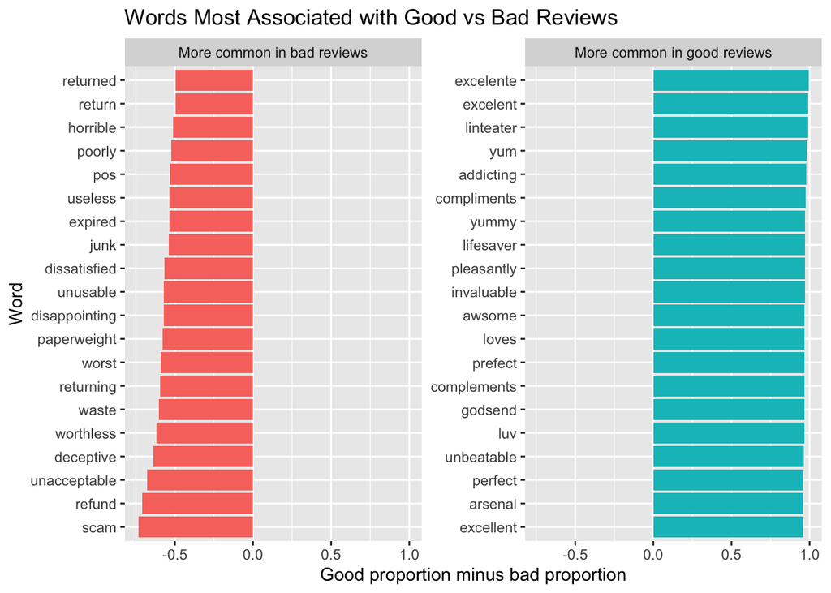

```r
plot_words <- bind_rows(
  bad_words %>% mutate(group = "More common in bad reviews"),
  good_words %>% mutate(group = "More common in good reviews")
)

ggplot(plot_words, aes(x = reorder(word, difference), y = difference, fill = group)) +
  geom_col(show.legend = FALSE) +
  facet_wrap(~ group, scales = "free_y") +
  coord_flip() +
  labs(
    title = "Words Most Associated with Good vs Bad Reviews",
    x = "Word",
    y = "Good proportion minus bad proportion"
  )
```

# Regression And Random Forest

The logistic regression and random forest models were trained from the terminal with `run_full_models.sh`. The script streams the full Amazon review file, skips the malformed final line, excludes 3-star reviews from the good/bad classification task, and uses the top 100 full-corpus words as binary document features. Identical feature patterns are compressed with sample weights so the models can use all labeled reviews without writing a huge model matrix to disk.

```r
full_model_summary %>%
  rename(
    Metric = metric,
    Value = value
  ) %>%
  kable()
```

| Metric | Value |
| --- | --- |
| bad_reviews | 862923 |
| complete_records | 6427547 |
| good_reviews | 5127069 |
| labeled_reviews | 5989992 |
| malformed_lines | 1 |
| neutral_reviews_skipped | 437555 |
| test_reviews | 1197491 |
| train_reviews | 4792501 |
| unique_test_patterns | 655240 |
| unique_train_patterns | 2359410 |

```r
full_model_metrics %>%
  mutate(
    accuracy = round(accuracy, 4)
  ) %>%
  rename(
    Model = model,
    Accuracy = accuracy,
    `Actual good / predicted good` = actual_good_pred_good,
    `Actual good / predicted bad` = actual_good_pred_bad,
    `Actual bad / predicted good` = actual_bad_pred_good,
    `Actual bad / predicted bad` = actual_bad_pred_bad
  ) %>%
  kable()
```

| Model | Accuracy | Actual good / predicted good | Actual good / predicted bad | Actual bad / predicted good | Actual bad / predicted bad |
| --- | --- | --- | --- | --- | --- |
| logistic_regression | 0.8855 | 998552 | 26776 | 110377 | 61786 |
| random_forest | 0.9035 | 1003014 | 22314 | 93223 | 78940 |

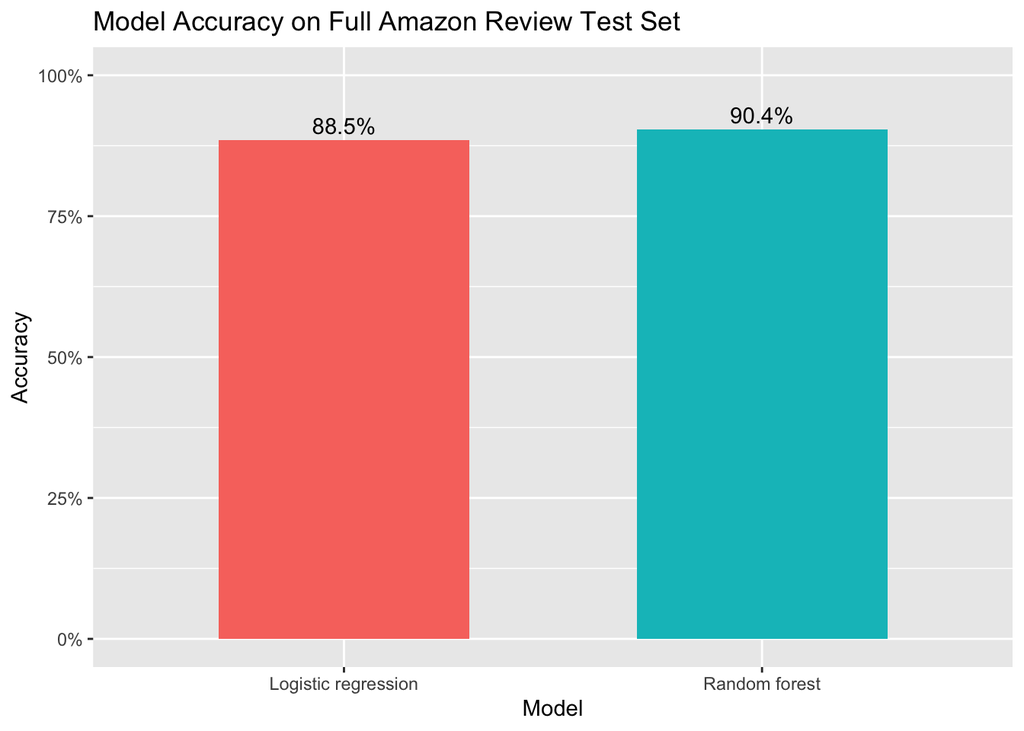

```r
model_accuracy <- full_model_metrics %>%
  mutate(
    Model = recode(
      model,
      logistic_regression = "Logistic regression",
      random_forest = "Random forest"
    )
  )

ggplot(model_accuracy, aes(x = Model, y = accuracy, fill = Model)) +
  geom_col(show.legend = FALSE, width = 0.6) +
  geom_text(
    aes(label = paste0(round(accuracy * 100, 1), "%")),
    vjust = -0.4
  ) +
  scale_y_continuous(
    labels = function(x) paste0(round(100 * x), "%"),
    limits = c(0, 1)
  ) +
  labs(
    title = "Model Accuracy on Full Amazon Review Test Set",
    x = "Model",
    y = "Accuracy"
  )
```

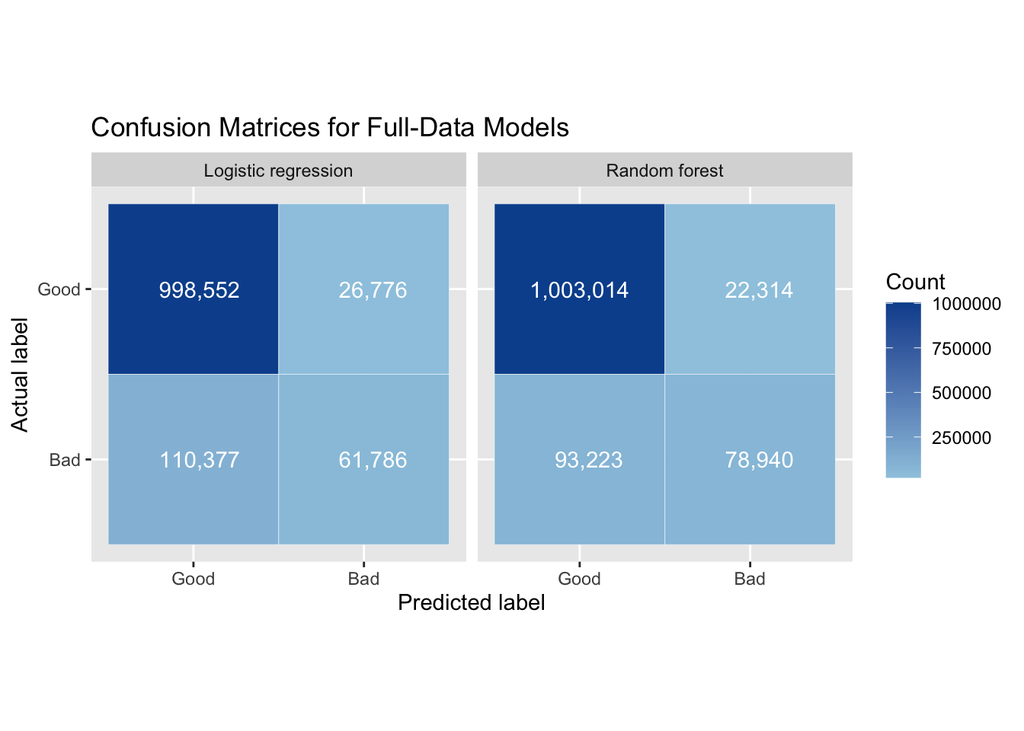

```r
model_confusion <- bind_rows(
  full_model_metrics %>%
    transmute(model, Actual = "Good", Predicted = "Good", Count = actual_good_pred_good),
  full_model_metrics %>%
    transmute(model, Actual = "Good", Predicted = "Bad", Count = actual_good_pred_bad),
  full_model_metrics %>%
    transmute(model, Actual = "Bad", Predicted = "Good", Count = actual_bad_pred_good),
  full_model_metrics %>%
    transmute(model, Actual = "Bad", Predicted = "Bad", Count = actual_bad_pred_bad)
) %>%
  mutate(
    Model = recode(
      model,
      logistic_regression = "Logistic regression",
      random_forest = "Random forest"
    ),
    Actual = factor(Actual, levels = c("Bad", "Good")),
    Predicted = factor(Predicted, levels = c("Good", "Bad"))
  )

ggplot(model_confusion, aes(x = Predicted, y = Actual, fill = Count)) +
  geom_tile(color = "white") +
  geom_text(aes(label = format(Count, big.mark = ",")), color = "white") +
  facet_wrap(~ Model) +
  coord_equal() +
  scale_fill_gradient(low = "#9ecae1", high = "#08519c") +
  labs(
    title = "Confusion Matrices for Full-Data Models",
    x = "Predicted label",
    y = "Actual label",
    fill = "Count"
  )
```

```r
logistic_coefficients %>%
  arrange(desc(coefficient_for_bad_review)) %>%
  head(15) %>%
  rename(
    Word = word,
    `Logistic coefficient for bad review` = coefficient_for_bad_review
  ) %>%
  kable()
```

| Word | Logistic coefficient for bad review |
| --- | --- |
| two | 1.4457567 |
| one | 1.1781810 |
| doesnt | 1.1154168 |
| didnt | 0.9039684 |
| dont | 0.8683860 |
| after | 0.8590177 |
| too | 0.8044769 |
| work | 0.7555403 |
| even | 0.7521095 |
| off | 0.7233964 |
| did | 0.7162781 |
| back | 0.6811983 |
| buy | 0.6120776 |
| amazon | 0.5676422 |
| then | 0.4869110 |

```r
logistic_coefficients %>%
  arrange(coefficient_for_bad_review) %>%
  head(15) %>%
  rename(
    Word = word,
    `Logistic coefficient for bad review` = coefficient_for_bad_review
  ) %>%
  kable()
```

| Word | Logistic coefficient for bad review |
| --- | --- |
| excellent | -2.7315989 |
| perfect | -2.7272848 |
| love | -2.3101346 |
| great | -2.0351936 |
| easy | -1.8442624 |
| best | -1.8097989 |
| nice | -1.3378867 |
| works | -1.2965909 |
| needed | -1.1354993 |
| good | -1.0205757 |
| well | -0.8970749 |
| little | -0.8021446 |
| far | -0.7945251 |
| price | -0.7423361 |
| need | -0.7034922 |

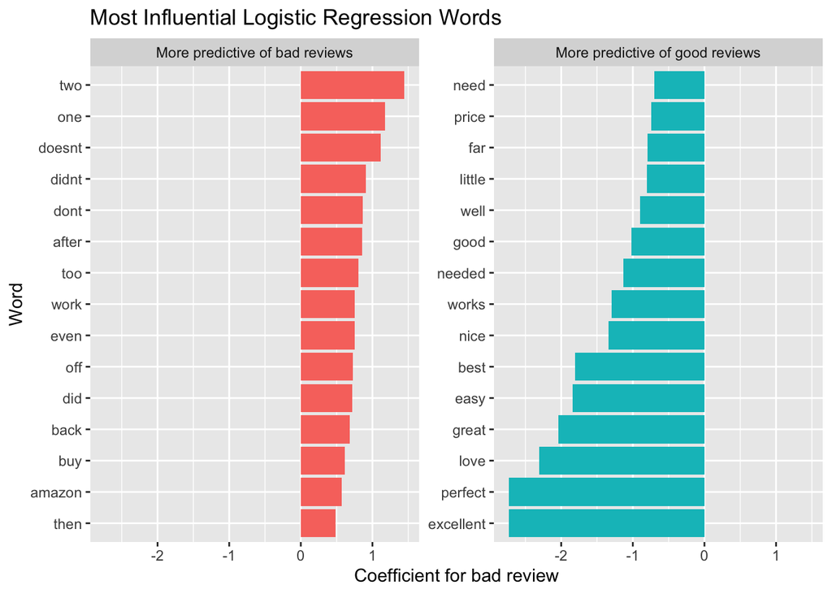

```r
logistic_plot_words <- bind_rows(
  logistic_coefficients %>%
    arrange(desc(coefficient_for_bad_review)) %>%
    head(15) %>%
    mutate(group = "More predictive of bad reviews"),
  logistic_coefficients %>%
    arrange(coefficient_for_bad_review) %>%
    head(15) %>%
    mutate(group = "More predictive of good reviews")
)

ggplot(
  logistic_plot_words,
  aes(
    x = reorder_within(word, coefficient_for_bad_review, group),
    y = coefficient_for_bad_review,
    fill = group
  )
) +
  geom_col(show.legend = FALSE) +
  facet_wrap(~ group, scales = "free_y") +
  scale_x_reordered() +
  coord_flip() +
  labs(
    title = "Most Influential Logistic Regression Words",
    x = "Word",
    y = "Coefficient for bad review"
  )
```

```r
random_forest_importance %>%
  head(20) %>%
  rename(
    Word = word,
    `Random forest importance` = importance
  ) %>%
  kable()
```

| Word | Random forest importance |
| --- | --- |
| great | 0.1090767 |
| one | 0.1029982 |
| two | 0.0751973 |
| love | 0.0504960 |
| perfect | 0.0318304 |
| easy | 0.0311889 |
| dont | 0.0293142 |
| good | 0.0285421 |
| after | 0.0278425 |
| best | 0.0264939 |
| works | 0.0260098 |
| didnt | 0.0249415 |
| work | 0.0243367 |
| doesnt | 0.0236206 |
| did | 0.0211522 |
| well | 0.0202938 |
| nice | 0.0190157 |
| excellent | 0.0165678 |
| buy | 0.0161870 |
| off | 0.0156860 |

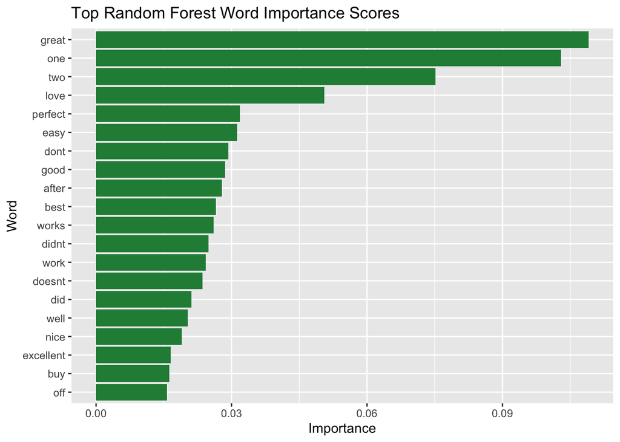

```r
random_forest_importance %>%
  head(20) %>%
  ggplot(aes(x = reorder(word, importance), y = importance)) +
  geom_col(fill = "#238b45") +
  coord_flip() +
  labs(
    title = "Top Random Forest Word Importance Scores",
    x = "Word",
    y = "Importance"
  )
```

# Modeling Note

The model results above come from the full terminal run saved in `results/full_models`. One important modeling choice is that the features are binary indicators for whether each top word appears in a review, rather than exact word counts. This keeps the full-dataset model feasible on the available disk space while still using every labeled complete review through sample weights.